# BAM tools help page

# eCerto (Certification statistics)

## General information

eCerto is an online tool written in R/Shiny to facilitate the statistical evaluation of data collected in connection with the production of reference materials at Bundesanstalt für Materialforschung und -prüfung (BAM).

The standard workflow consistes of a certification trial in combination with homogeneity and stability assays. Data from all of these assays need to be collected, combined and analyzed to report certified values of measured properties or entities of a reference material.

### User/Study information and data backup/retrieval

For the eCerto module of the software you should provide a user name and trial ID which will be stored together with your data (‘Save Current Analysis’).

Previous analyses can be read from a backup file and will contain all input data and previously set parameters.

## Certification

### Data upload from Excel for a new analysis

To process a new analysis, please collect all data which should be retuned in pre-defined Excel-Files by your certification trial partners and stored within one folder. Pre-defined means that the analytical results are at the same position within each file (table name, row and column range) and that one file per laboratory exists.

**Note!** “Header row should be specified but will not be evaluated. eCerto assumes the first and second column to contain analyte names and units respectively and replicate measurements of this analyte in all remaining columns.”,

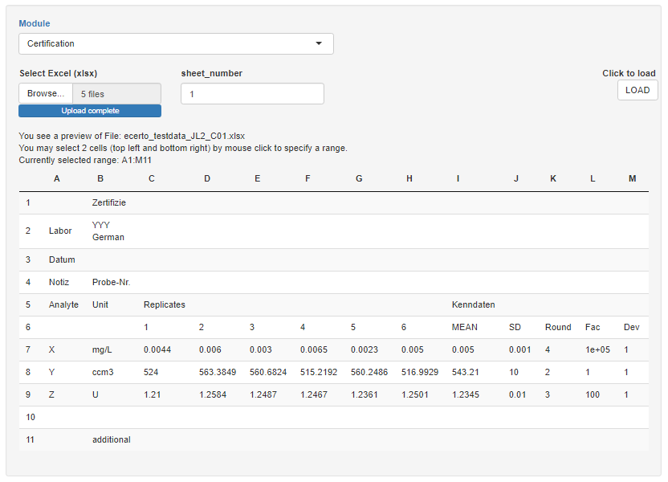

Data upload from Excel with preview

**Note!** "Currently, eCerto needs to load all Excel-result files in one step, i.e. you can not add additional files later on but would have to start all over again.

### Laboratory statistics to identify potentially outliers for lab means and lab variances

For the selected analyte various statistical tests regarding lab means and variance will be performed according to ISO 17025 and outlying values will be indicated if observed at the $.05$ and $.01$ level respectively. `n.s.` and `.` indicate that the test probability was $>0.05$ or this lab was not tested.

Except for `Cochran`, which tests for outliers with respect to variance, all other columns indicate potential outliers regarding lab means.

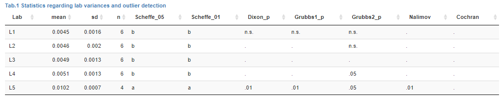

Laboratory statistics example

eCerto uses functions available for the statistical software environment R. Details regarding the conducted statistical test (implementation, parameters) can be found using the following links:

- [Scheffe](https://rdrr.io/cran/agricolae/man/scheffe.test.html) *Note!* Similar letters indicate similar group and hence no difference.
- [Dixon](https://rdrr.io/cran/outliers/man/dixon.test.html)
- [Grubbs](https://rdrr.io/cran/outliers/man/grubbs.test.html) *Note!* Test is performed as single (only most extreme value is tested) as well as double version (two most extreme values are tested against the rest).
- [Nalimov](http://www.statistics4u.info/fundstat_germ/ee_nalimov_outliertest.html)
- [Cochran](https://rdrr.io/cran/outliers/man/cochran.test.html) *Note!* Test is performed consecutively, i.e. the Lab showing the highest variance is tested first. If significant, it is removed and the procedure is repeated. `excl` indicates that the `sd` of a lab was too low and the lab was removed from the testing procedure.

### Statistics on the distribution of lab means

The distribution of lab means is evaluated using a variety of recommended tests. Normality of the distribution is tested using the KS-Test. Besides `mean` and `sd` the robust alternatives `median` and `MAD`are provided. Columns which end on `_p` provide P-values of the respective tests. Skewness and Kurtosis are computed additionally and grouped with their respective tests (Agostino and Anscombe).

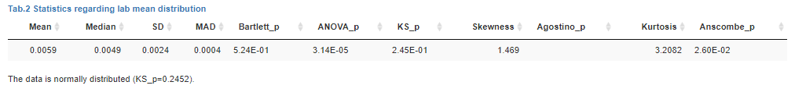

Statistics regarding Lab mean distribution

Details regarding the conducted statistical test can be found using the following links:

- [Bartlett](https://rdrr.io/cran/stats/man/bartlett.test.html)
- [ANOVA](https://rdrr.io/cran/stats/man/anova.html)
- [KS](https://rdrr.io/cran/stats/man/ks.test.html)
- [Skewness](https://rdrr.io/cran/moments/man/skewness.html)
- [Agostino](https://rdrr.io/cran/moments/man/agostino.test.html)
- [Kurtosis](https://rdrr.io/cran/moments/man/kurtosis.html)
- [Anscombe](https://rdrr.io/cran/moments/man/anscombe.test.html)

*Note!* Some tests need a minimum number of replicates and will not yield a result if this criteria is not met (i.e. Agostino).

### Certified value calculation and vizualization of the currently selected analyte

Lab means and distribution is depicted in a standard graphic layout which can be exported as vector graphic (PDF) for further editing. Labs which have been identified as outliers above can be excluded from the overall mean calculation. This decision has to be made by the user, eCerto will not remove an outlier lab automatically.

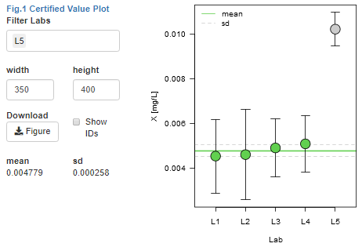

Certified Value Plot with filtered Lab

### Report

A report of the above analysis (single analyte) or for the material (all analytes) can be generated and exported in different formats.

## Homogeneity

### Data Upload

Please prepare all data in a single Excel file on the first table (other tables will be neglected). Please stick to the header/format as given in the below example. The `analyte` column should contain values that match the corresponding data from the certification module. `H_type` can be used to define different homogeneity traits for each analyte which can yield independent uncertainty contributions. `Flasche` encodes the different samples where repeated measurements have been performed on. `value`/ `unit` have to be determined similarly to the data from the certification trial obviously to yield a meaningful uncertainty value.

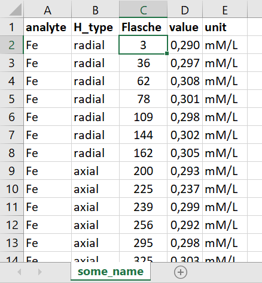

### Statistics

The uncertainty contribution of the Homogeneity measurements `U_bb` is calculated for each analyte based on formula and is transfered to the materials table of the certification module in case that an analyte of matching name is found.

### Report

Figures and tables can currently be exported in a HTML format.

### Uncertainty

Conducting the analysis of variance (ANOVA) on a one factor linear model we determined from $N$ bottles/containers with $n$ replicates each the variance within bottles $s_w$ (MS_within) and the variance between bottles $s_a$ (MS_among). Together with the overall mean vlaue $\mu$ (mean of all $N$ bottle means), we now can compute two relative uncertainties between bottles:

$$s_{bb}={\sqrt{s_a-s_w \over n} \over \mu}$$

and

$$s_{bb, min}={\sqrt{s_w/n}*\frac{2}{N*(n-1)}^{1/4} \over \mu}$$

The larger of both values, $s_{bb}$ and $s_{bb,min}$, is transfered as uncertainty contribution to the column in the material table selected by the user.

*Note!* $s_{bb}=0$ for $s_{a} < s{_w}$

## Stability

### Data upload

Please prepare data in a single Excel file on seperate tables for each analyte as shown in the below example. Table names have to match analyte names from the Certification module. Column names need to be exactly `Value` and `Date` and column format should be numeric and date respectively.

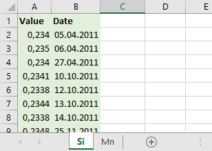

Upload can be also achieved from a previousy created backup file. If a backup file does not contain any stability data, the Excel upload option will remain active but will be deactivated otherwise.

### Uncertainty calculation

The uncertainty contribution of the stability measurements `U_Stab` is calculated for each analyte based on a linear model of `Value` on `Date`. The parameters of each model are combined using formula
$$U_{Stab}=abs(m*err)$$
where $m$ is the `slope` of the linear model and $err$ is the standard error `SE` of the slope.

*Note!* Clicking on a table row will display the analysis for this analyte.

`U_Stab` can be transfered to the material table of the certification module in case that matching analyte names are found.

## Material table

The material table combines all data collected within a certification trial to provide for each measured entity within the certified material the certified mean `cert_val` and the certified uncertainty `U`.

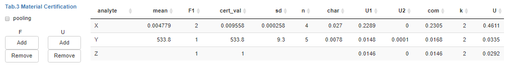

Materialtabelle

*Note!* Only for analytes which have been visually inspected by the user certified values will be transfered to this table to ensure that inspection took place.

Several columns of the material table can be edited by the user by clicking in an individual cell and entering a new value.

Table column descriptions:

The material table can be exported together with a report as PDF, Word or HTML document.

# Long Term Stability (LTS)

### Data Upload

Please prepare data in a single Excel file on seperate tables for each measured value (KW, Kennwert) as shown in the below example. Table/File names are not evaluated. Instead, each table is expected to contain the metadata in rows 1-2 and the measurement data from row 4 onwards. Column names need to be exactly as in the example and should match the desired format (e.g. ‘Value’ and ‘Date’ columns should be of numeric and date format respectively).

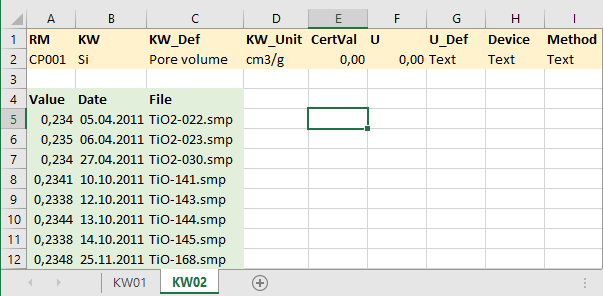

### Statistics

The Tool calculates the expected life time of a reference material in several steps:

- calculating a linear model for the measurement data $y=m*x+n$, where $y$ represent measured values and $x$ represents time (expressed in month) and
- correcting the intercept $n$ for the difference between the mean obtained from LTS data and the mean reported as certified value on import $n'=n+mean-cert\_val$
- using the corrected $n'$ and $m$ to estimate the timepoint when the value of the certified analyte is expected to exceede the range of $cert\_val\pm~U$.

### User interaction

After data upload, the user can:

- add new data points
- add comments to any data point
- download a PDF report

### Report

The user can export a PDF report containing all imported, edited and calculated data and figures.